# machinelearning

Giuseppe Albanese

Wednesday, October 22, 2014

# Backgound information

In this project we will build a machine learning algorithm to predict activity quality from activity monitors.

Our goal will be to use data from accelerometers on the belt, forearm, arm, and dumbell of 6 participants. They were asked to perform barbell lifts correctly and incorrectly in 5 different ways.

The data for this project come from this source: http://groupware.les.inf.puc-rio.br/har.

Since this is a **classification** problem we will explore **random forest** algorithm to build our model.

We will also make a 5-fold crossvalidation and try to give an OOB estimation of error rate.

# Getting and cleaning the data

## get the data

```r
#if (!file.exists("./pml-training.csv")) {
#        fileUrl <- "https://d396qusza40orc.cloudfront.net/predmachlearn/pml-training.csv"
#        download.file(fileUrl, destfile = "./pml-training.csv")
#        }

#if (!file.exists("./pml-testing.csv")) {
#        fileUrl <- "https://d396qusza40orc.cloudfront.net/predmachlearn/pml-testing.csv"
#        download.file(fileUrl, destfile = "./pml-testing.csv")
#        }

pmltraining <- read.csv("./pml-training.csv")

pmltesting <- read.csv("./pml-testing.csv")
```

## explore the data

```r
attach(pmltraining)

summary(amplitude_yaw_forearm)
```

```
##         #DIV/0!    0.00
##   19216      84     322
```

```r
summary(var_accel_forearm)
```

```
##    Min. 1st Qu.  Median    Mean 3rd Qu.    Max.    NA's
##       0       7      21      34      51     173   19216
```

```r
detach(pmltraining)
```

we see that a lot of rows in these columns are blank or are NA

## prepare and remove columns that are blank and columns that are NA

```r
pmltraining[pmltraining==""] <- NA

#colSums(is.na(pmltraining))

pmltraining <- pmltraining[, colSums(is.na(pmltraining)) == 0]

#summary(pmltraining)

table(pmltraining$user_name,pmltraining$classe)
```

```
##
##               A    B    C    D    E
##   adelmo   1165  776  750  515  686
##   carlitos  834  690  493  486  609
##   charles   899  745  539  642  711
##   eurico    865  592  489  582  542
##   jeremy   1177  489  652  522  562
##   pedro     640  505  499  469  497
```

## keep only variables related to sensor measurements, classe and user_name

```r
train <- cbind(pmltraining[,8:ncol(pmltraining)], user=pmltraining$user_name)
```

# Build the prediction model

## partition data in training and testing

```r
library(caret)
set.seed(1234)

inTrain <- createDataPartition(y=train$classe, p=0.70, list=FALSE)

training <- train[inTrain,]

testing <- train[-inTrain,]
```

## visualize data

Function densityp shows density plots for a feature splitted by classe and faceted by user.

This could be usefull to select “good” features.

Parameter i corresponds to a column number.

```r
library(ggplot2)

densityp <- function(i) {
        feature <- names(training)[i]
        ggplot(training, aes_string(x=feature, colour="classe")) +
                geom_density() +
                facet_wrap(~ user)
        }
```

## example for magnet_forearm_x feature :

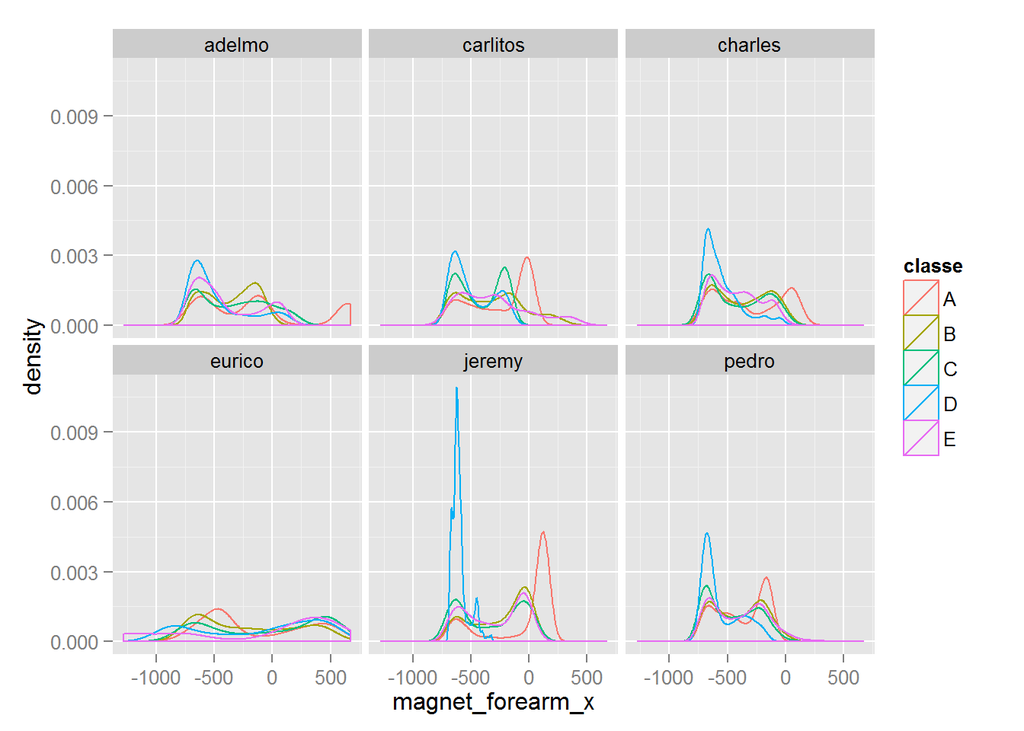

```r
densityp(50)
```

This plot shows that magnet forearm x could be “good” to make a distinction between classe A and classe D for carlitos, charles, jeremy and pedro.

We will not explore more features here.

## train a random forest model using 5-fold cross valaidation

```r
#Sys.time()

modFit <- train(classe ~ . - user, data=training, method="rf",
                trControl=trainControl(method="cv", number=5),  prox=TRUE)
#Sys.time()

modFit$finalModel
```

```
##
## Call:
##  randomForest(x = x, y = y, mtry = param$mtry, proximity = TRUE)
##                Type of random forest: classification
##                      Number of trees: 500
## No. of variables tried at each split: 2
##
##         OOB estimate of  error rate: 0.58%
## Confusion matrix:
##      A    B    C    D    E class.error
## A 3903    2    0    0    1    0.000768
## B   11 2644    3    0    0    0.005267
## C    0   21 2374    1    0    0.009182
## D    0    0   33 2218    1    0.015098
## E    0    0    1    5 2519    0.002376
```

The final model gives an OOB estimation of error rate.

## evaluate model on testing

```r
predtesting <- predict(modFit, testing)

accuracy <- confusionMatrix(predtesting, testing$classe)$overall[1]

accuracy
```

```
## Accuracy
##   0.9947
```

The value of accuracy corresponds to OOB estimation of error rate.

## make predictions on pmltesting

we have to cleanup pmltesting the same way we cleaned pmltraining.

```r
pmltesting[pmltesting==""] <- NA

pmltesting <- pmltesting[, colSums(is.na(pmltesting)) == 0]

testcleaned <- cbind(pmltesting[,8:ncol(pmltesting)], user=pmltesting$user_name)

predictions <- predict(modFit,testcleaned)

predictions
```

```
##  [1] B A B A A E D B A A B C B A E E A B B B
## Levels: A B C D E
```